# 08. Neural Network

```python
import tensorflow as tf
from tensorflow.keras.utils import plot_model
```

```python
import numpy as np
import matplotlib.pyplot as plt
import seaborn as sns
```

```python
import os
os.environ['PATH'] += os.pathsep + 'D:/Graphviz/bin/'
```

```python
mnist = tf.keras.datasets.mnist

(x_train, y_train),(x_test, y_test) = mnist.load_data()
x_train, x_test = x_train / 255.0, x_test / 255.0

model = tf.keras.models.Sequential([
  tf.keras.layers.Flatten(input_shape=(28, 28)),
  tf.keras.layers.Dense(128, activation='relu'),
  tf.keras.layers.Dropout(0.2),
  tf.keras.layers.Dense(10, activation='softmax')
])

model.compile(optimizer='adam',
              loss='sparse_categorical_crossentropy',
              metrics=['accuracy'])

model.fit(x_train, y_train, epochs=5)
model.evaluate(x_test, y_test)
```

```
[0.07657180726528168, 0.9753999710083008]
```

```python
tf.__version__
```

```
'2.4.1'
```

```python
import pandas as pd
from sklearn.datasets import load_boston

boston = load_boston()
dir(boston)
dfX = pd.DataFrame(boston.data, columns = boston.feature_names)
dfy = pd.DataFrame(boston.target, columns = ['MEDV'])

df = pd.concat([dfX,dfy], axis=1)
df
```

|  | CRIM | ZN | INDUS | CHAS | NOX | RM | AGE | DIS | RAD | TAX | PTRATIO | B | LSTAT | MEDV |
| --- | --- | --- | --- | --- | --- | --- | --- | --- | --- | --- | --- | --- | --- | --- |
| 0 | 0.00632 | 18.0 | 2.31 | 0.0 | 0.538 | 6.575 | 65.2 | 4.0900 | 1.0 | 296.0 | 15.3 | 396.90 | 4.98 | 24.0 |
| 1 | 0.02731 | 0.0 | 7.07 | 0.0 | 0.469 | 6.421 | 78.9 | 4.9671 | 2.0 | 242.0 | 17.8 | 396.90 | 9.14 | 21.6 |
| 2 | 0.02729 | 0.0 | 7.07 | 0.0 | 0.469 | 7.185 | 61.1 | 4.9671 | 2.0 | 242.0 | 17.8 | 392.83 | 4.03 | 34.7 |
| 3 | 0.03237 | 0.0 | 2.18 | 0.0 | 0.458 | 6.998 | 45.8 | 6.0622 | 3.0 | 222.0 | 18.7 | 394.63 | 2.94 | 33.4 |
| 4 | 0.06905 | 0.0 | 2.18 | 0.0 | 0.458 | 7.147 | 54.2 | 6.0622 | 3.0 | 222.0 | 18.7 | 396.90 | 5.33 | 36.2 |
| ... | ... | ... | ... | ... | ... | ... | ... | ... | ... | ... | ... | ... | ... | ... |
| 501 | 0.06263 | 0.0 | 11.93 | 0.0 | 0.573 | 6.593 | 69.1 | 2.4786 | 1.0 | 273.0 | 21.0 | 391.99 | 9.67 | 22.4 |
| 502 | 0.04527 | 0.0 | 11.93 | 0.0 | 0.573 | 6.120 | 76.7 | 2.2875 | 1.0 | 273.0 | 21.0 | 396.90 | 9.08 | 20.6 |
| 503 | 0.06076 | 0.0 | 11.93 | 0.0 | 0.573 | 6.976 | 91.0 | 2.1675 | 1.0 | 273.0 | 21.0 | 396.90 | 5.64 | 23.9 |
| 504 | 0.10959 | 0.0 | 11.93 | 0.0 | 0.573 | 6.794 | 89.3 | 2.3889 | 1.0 | 273.0 | 21.0 | 393.45 | 6.48 | 22.0 |
| 505 | 0.04741 | 0.0 | 11.93 | 0.0 | 0.573 | 6.030 | 80.8 | 2.5050 | 1.0 | 273.0 | 21.0 | 396.90 | 7.88 | 11.9 |

506 rows × 14 columns

```python
df.shape
```

```
(506, 14)
```

```python
df.info()
```

```
<class 'pandas.core.frame.DataFrame'>
RangeIndex: 506 entries, 0 to 505
Data columns (total 14 columns):
 #   Column   Non-Null Count  Dtype
---  ------   --------------  -----
 0   CRIM     506 non-null    float64
 1   ZN       506 non-null    float64
 2   INDUS    506 non-null    float64
 3   CHAS     506 non-null    float64
 4   NOX      506 non-null    float64
 5   RM       506 non-null    float64
 6   AGE      506 non-null    float64
 7   DIS      506 non-null    float64
 8   RAD      506 non-null    float64
 9   TAX      506 non-null    float64
 10  PTRATIO  506 non-null    float64
 11  B        506 non-null    float64
 12  LSTAT    506 non-null    float64
 13  MEDV     506 non-null    float64
dtypes: float64(14)
memory usage: 55.5 KB
```

```python
df.isnull().sum() #결측치확인
```

```
CRIM       0
ZN         0
INDUS      0
CHAS       0
NOX        0
RM         0
AGE        0
DIS        0
RAD        0
TAX        0
PTRATIO    0
B          0
LSTAT      0
MEDV       0
dtype: int64
```

```python
dataset_new = df.copy().loc[:,['INDUS','RM','AGE','TAX','DIS','MEDV']] # 일부만 선택
```

```python
dataset_new
```

|  | INDUS | RM | AGE | TAX | DIS | MEDV |
| --- | --- | --- | --- | --- | --- | --- |
| 0 | 2.31 | 6.575 | 65.2 | 296.0 | 4.0900 | 24.0 |
| 1 | 7.07 | 6.421 | 78.9 | 242.0 | 4.9671 | 21.6 |
| 2 | 7.07 | 7.185 | 61.1 | 242.0 | 4.9671 | 34.7 |
| 3 | 2.18 | 6.998 | 45.8 | 222.0 | 6.0622 | 33.4 |
| 4 | 2.18 | 7.147 | 54.2 | 222.0 | 6.0622 | 36.2 |
| ... | ... | ... | ... | ... | ... | ... |
| 501 | 11.93 | 6.593 | 69.1 | 273.0 | 2.4786 | 22.4 |
| 502 | 11.93 | 6.120 | 76.7 | 273.0 | 2.2875 | 20.6 |
| 503 | 11.93 | 6.976 | 91.0 | 273.0 | 2.1675 | 23.9 |
| 504 | 11.93 | 6.794 | 89.3 | 273.0 | 2.3889 | 22.0 |
| 505 | 11.93 | 6.030 | 80.8 | 273.0 | 2.5050 | 11.9 |

506 rows × 6 columns

# 기초통계

```python
dataset_new.mean()
```

```
INDUS     11.136779
RM         6.284634
AGE       68.574901
TAX      408.237154
DIS        3.795043
MEDV      22.532806
dtype: float64
```

```python
dataset_new.var()
```

```
INDUS       47.064442
RM           0.493671
AGE        792.358399
TAX      28404.759488
DIS          4.434015
MEDV        84.586724
dtype: float64
```

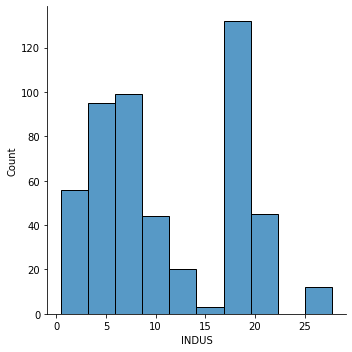

```python
sns.displot(data=dataset_new["INDUS"])
plt.show()
```

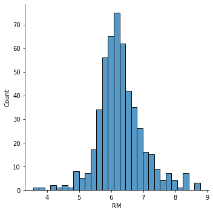

```python
sns.displot(data=dataset_new["RM"])
plt.show()
```

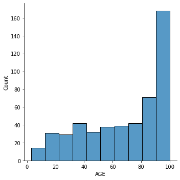

```python
sns.displot(data=dataset_new["AGE"])
plt.show()
```

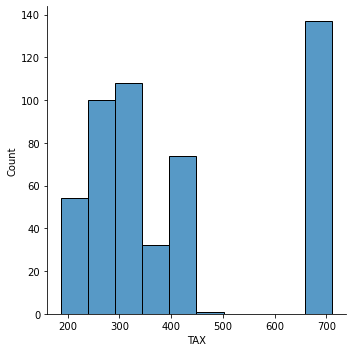

```python
sns.displot(data=dataset_new["TAX"])
plt.show()
```

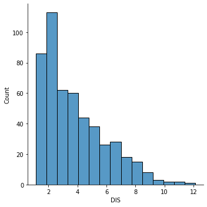

```python
sns.displot(data=dataset_new["DIS"])
plt.show()
```

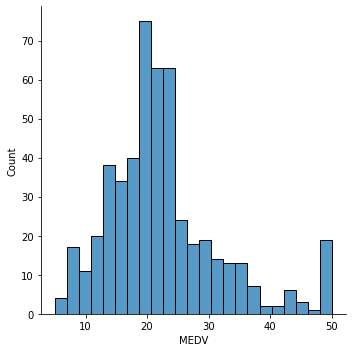

```python
sns.displot(data=dataset_new["MEDV"])
plt.show()
```

```python
dataset_new.corr()
```

|  | INDUS | RM | AGE | TAX | DIS | MEDV |
| --- | --- | --- | --- | --- | --- | --- |
| INDUS | 1.000000 | -0.391676 | 0.644779 | 0.720760 | -0.708027 | -0.483725 |
| RM | -0.391676 | 1.000000 | -0.240265 | -0.292048 | 0.205246 | 0.695360 |
| AGE | 0.644779 | -0.240265 | 1.000000 | 0.506456 | -0.747881 | -0.376955 |
| TAX | 0.720760 | -0.292048 | 0.506456 | 1.000000 | -0.534432 | -0.468536 |
| DIS | -0.708027 | 0.205246 | -0.747881 | -0.534432 | 1.000000 | 0.249929 |
| MEDV | -0.483725 | 0.695360 | -0.376955 | -0.468536 | 0.249929 | 1.000000 |

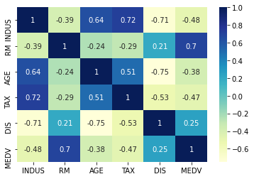

```python
sns.heatmap(dataset_new.corr(), annot=True, cmap="YlGnBu")
plt.show()
```

```python
# Features와 target 나누기
features = dataset_new[dataset_new.columns[:-1]]
target = dataset_new[dataset_new.columns[-1]]
```

```python
# train: test = 8:2 분리
from sklearn.model_selection import train_test_split
train_features, test_features , train_target, test_target = train_test_split(
    features, target, test_size = 0.2, random_state = 2021)
```

```python
print(train_features.shape)
print(train_target.shape)
print(test_features.shape)
print(test_target.shape)
```

```
(404, 5)
(404,)
(102, 5)
(102,)
```

```python
print(type(train_features))
print(type(train_target))
```

```
<class 'pandas.core.frame.DataFrame'>
<class 'pandas.core.series.Series'>
```

```python
import pandas as pd
pd.DataFrame(train_features.copy())
```

|  | INDUS | RM | AGE | TAX | DIS |
| --- | --- | --- | --- | --- | --- |
| 28 | 8.14 | 6.495 | 94.4 | 307.0 | 4.4547 |
| 498 | 9.69 | 6.019 | 65.3 | 391.0 | 2.4091 |
| 284 | 2.97 | 7.088 | 20.8 | 285.0 | 7.3073 |
| 414 | 18.10 | 4.519 | 100.0 | 666.0 | 1.6582 |
| 123 | 25.65 | 5.856 | 97.0 | 188.0 | 1.9444 |
| ... | ... | ... | ... | ... | ... |
| 109 | 8.56 | 6.229 | 91.2 | 384.0 | 2.5451 |
| 128 | 21.89 | 6.431 | 98.8 | 437.0 | 1.8125 |
| 57 | 1.32 | 6.816 | 40.5 | 256.0 | 8.3248 |
| 341 | 1.52 | 7.241 | 49.3 | 284.0 | 7.0379 |
| 116 | 10.01 | 6.176 | 72.5 | 432.0 | 2.7301 |

404 rows × 5 columns

```python
pd.DataFrame(train_target.copy())
```

|  | MEDV |
| --- | --- |
| 28 | 18.4 |
| 498 | 21.2 |
| 284 | 32.2 |
| 414 | 7.0 |
| 123 | 17.3 |
| ... | ... |
| 109 | 19.4 |
| 128 | 18.0 |
| 57 | 31.6 |
| 341 | 32.7 |
| 116 | 21.2 |

404 rows × 1 columns

```python
# Z-score Standardization

mean = train_features.mean(axis=0)
train_features -= mean
std = train_features.std(axis=0)
train_features /= std
```

```python
# test data (Features)도 train의 기준으로 표준화
test_features -= mean
test_features /= std
```

# Modeling 시작

## Learning rate = 0.1

1) Hidden Layer = 1, Hidden Node = 8, learning rate = 0.1

```python
# Network 구조 형성
import tensorflow as tf
from tensorflow.keras import models
from tensorflow.keras import layers

# tf.set_random_seed(2021) <- 이건 tensorflow 1 version
tf.random.set_seed(2021)

# 1 #
model1 = models.Sequential() # ANN 형성
model1.add(layers.Dense(8, activation = 'relu', input_shape=(train_features.shape[1],)))
model1.add(layers.Dense(1)) # Output layer - regression은 node가 1개

# 2 #
# loss function과 optimizer 설정
adam = tf.keras.optimizers.Adam(learning_rate=0.1)

# 3 #
model1.compile(optimizer=adam, loss='mse', metrics=['mape'])

# 콜백 함수 #
es = tf.keras.callbacks.EarlyStopping(monitor='val_loss', patience=10, verbose=1, restore_best_weights=True) # Early stopping
lr = tf.keras.callbacks.ReduceLROnPlateau(monitor='val_loss', factor=0.1, min_lr=0.001) # learning rate 관련


# 4 #
# model.fit(train_data, train_targets, epochs=80, batch_size=16)
reg_history1 = model1.fit(train_features, train_target, epochs=300, batch_size=1024, validation_split=0.2,
                       callbacks=[es,lr])
```

```
Restoring model weights from the end of the best epoch.
Epoch 00074: early stopping
```

```python
model1.summary()
```

```
Model: "sequential_1"
_________________________________________________________________
Layer (type)                 Output Shape              Param #
=================================================================
dense_2 (Dense)              (None, 8)                 48
_________________________________________________________________
dense_3 (Dense)              (None, 1)                 9
=================================================================
Total params: 57
Trainable params: 57
Non-trainable params: 0
_________________________________________________________________
```

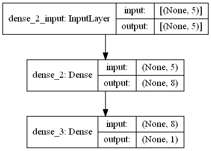

```python
plot_model(model1, to_file='network_regression_model_shapes_1.png', show_shapes=True)
```

```python
reg_history_dict_1 = reg_history1.history
reg_history_dict_1.keys()
```

```
dict_keys(['loss', 'mape', 'val_loss', 'val_mape', 'lr'])
```

```python
reg_history1.history
```

[output not shown]

[output cut: 315 more lines]

[output not shown]

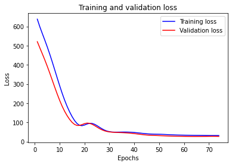

```python
# 훈련과 검증 손실 (loss)
import matplotlib.pyplot as plt
reg_history_dict_1 = reg_history1.history
loss_1 = reg_history_dict_1['loss']
val_loss_1 = reg_history_dict_1['val_loss']

epochs_1 = range(1, len(loss_1) + 1)

plt.plot(epochs_1, loss_1, 'b', label='Training loss')
plt.plot(epochs_1, val_loss_1, label='Validation loss', color='red') # ‘b’는 실선으로, 'bo'는 점으로 나옴
plt.title('Training and validation loss')
plt.xlabel('Epochs')
plt.ylabel('Loss')
plt.legend()

plt.show()
```

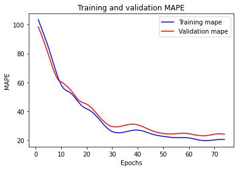

```python
# 따로 표현하기 2
# 훈련과 검증 MAPE (metric)
plt.clf() # 그래프를 초기화합니다.
train_metric_1 = reg_history_dict_1['mape']
val_metric_1 = reg_history_dict_1['val_mape']

plt.plot(epochs_1, train_metric_1, 'b', label='Training mape')
plt.plot(epochs_1, val_metric_1, label='Validation mape', color='red')
plt.title('Training and validation MAPE')
plt.xlabel('Epochs')
plt.ylabel('MAPE')
plt.legend()

plt.show()
```

```python
y_pred_1 = model1.predict(test_features)
```

```python
# 성능평가
from sklearn.metrics import r2_score, mean_squared_error, mean_absolute_percentage_error
print('test R squared: %.3f' % r2_score(test_target, y_pred_1))
print('test MSE: %.3f' % mean_squared_error(test_target,y_pred_1))
print('tset MAPE: %.3f' % mean_absolute_percentage_error(test_target,y_pred_1))
```

```
test R squared: 0.578
test MSE: 26.930
tset MAPE: 0.220
```

2) Hidden Layer = 1, Hidden Node = 16, learning rate = 0.1

```python
# Network 구조 형성
import tensorflow as tf
from tensorflow.keras import models
from tensorflow.keras import layers

# tf.set_random_seed(2021) <- 이건 tensorflow 1 version
tf.random.set_seed(2021)

# 1 #
model2 = models.Sequential() # ANN 형성
model2.add(layers.Dense(16, activation = 'relu', input_shape=(train_features.shape[1],)))
model2.add(layers.Dense(1)) # Output layer - regression은 node가 1개

# 2 #
# loss function과 optimizer 설정
adam = tf.keras.optimizers.Adam(learning_rate=0.1)

# 3 #
model2.compile(optimizer=adam, loss='mse', metrics=['mape'])

# 콜백 함수 #
es = tf.keras.callbacks.EarlyStopping(monitor='val_loss', patience=10, verbose=1, restore_best_weights=True) # Early stopping
lr = tf.keras.callbacks.ReduceLROnPlateau(monitor='val_loss', factor=0.1, min_lr=0.001) # learning rate 관련


# 4 #
# model.fit(train_data, train_targets, epochs=80, batch_size=16)
reg_history2 = model2.fit(train_features, train_target, epochs=300, batch_size=1024, validation_split=0.2,
                       callbacks=[es,lr])
```

```
Restoring model weights from the end of the best epoch.
Epoch 00055: early stopping
```

```python
model2.summary()
```

```
Model: "sequential_2"
_________________________________________________________________
Layer (type)                 Output Shape              Param #
=================================================================
dense_4 (Dense)              (None, 16)                96
_________________________________________________________________
dense_5 (Dense)              (None, 1)                 17
=================================================================
Total params: 113
Trainable params: 113
Non-trainable params: 0
_________________________________________________________________
```

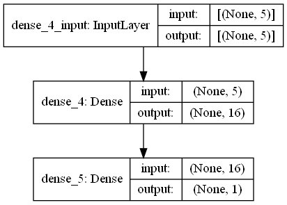

```python
plot_model(model2, to_file='network_regression_model_shapes_2.png', show_shapes=True)
```

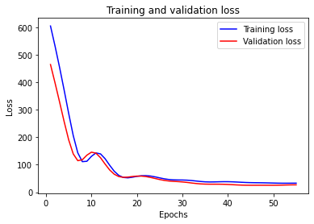

```python
# 훈련과 검증 손실 (loss)
import matplotlib.pyplot as plt
reg_history_dict_2 = reg_history2.history
loss_2 = reg_history_dict_2['loss']
val_loss_2 = reg_history_dict_2['val_loss']

epochs_2 = range(1, len(loss_2) + 1)

plt.plot(epochs_2, loss_2, 'b', label='Training loss')
plt.plot(epochs_2, val_loss_2, label='Validation loss', color='red') # ‘b’는 실선으로, 'bo'는 점으로 나옴
plt.title('Training and validation loss')
plt.xlabel('Epochs')
plt.ylabel('Loss')
plt.legend()

plt.show()
```

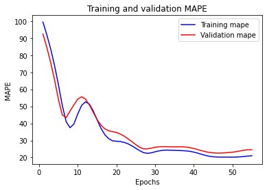

```python
# 따로 표현하기 2
# 훈련과 검증 MAPE (metric)
plt.clf() # 그래프를 초기화합니다.
train_metric_2 = reg_history_dict_2['mape']
val_metric_2 = reg_history_dict_2['val_mape']

plt.plot(epochs_2, train_metric_2, 'b', label='Training mape')
plt.plot(epochs_2, val_metric_2, label='Validation mape', color='red')
plt.title('Training and validation MAPE')
plt.xlabel('Epochs')
plt.ylabel('MAPE')
plt.legend()

plt.show()
```

```python
y_pred_2 = model2.predict(test_features)
```

```python
# 성능평가
from sklearn.metrics import r2_score, mean_squared_error, mean_absolute_percentage_error
print('test R squared: %.3f' % r2_score(test_target, y_pred_2))
print('test MSE: %.3f' % mean_squared_error(test_target,y_pred_2))
print('tset MAPE: %.3f' % mean_absolute_percentage_error(test_target,y_pred_2))
```

```
test R squared: 0.583
test MSE: 26.630
tset MAPE: 0.221
```

3) Hidden Layer = 2, Hidden Node = [8,16] , learning rate = 0.1

```python
# Network 구조 형성
import tensorflow as tf
from tensorflow.keras import models
from tensorflow.keras import layers

# tf.set_random_seed(2021) <- 이건 tensorflow 1 version
tf.random.set_seed(2021)

# 1 #
model3 = models.Sequential() # ANN 형성
model3.add(layers.Dense(8, activation = 'relu', input_shape=(train_features.shape[1],)))
model3.add(layers.Dense(16, activation = 'relu', input_shape=(train_features.shape[1],)))
model3.add(layers.Dense(1)) # Output layer - regression은 node가 1개

# 2 #
# loss function과 optimizer 설정
adam = tf.keras.optimizers.Adam(learning_rate=0.1)

# 3 #
model3.compile(optimizer=adam, loss='mse', metrics=['mape'])

# 콜백 함수 #
es = tf.keras.callbacks.EarlyStopping(monitor='val_loss', patience=10, verbose=1, restore_best_weights=True) # Early stopping
lr = tf.keras.callbacks.ReduceLROnPlateau(monitor='val_loss', factor=0.1, min_lr=0.001) # learning rate 관련


# 4 #
# model.fit(train_data, train_targets, epochs=80, batch_size=16)
reg_history3 = model3.fit(train_features, train_target, epochs=300, batch_size=1024, validation_split=0.2,
                       callbacks=[es,lr])
```

```
Restoring model weights from the end of the best epoch.
Epoch 00055: early stopping
```

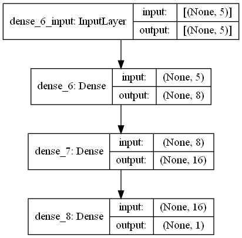

```python
plot_model(model3, to_file='network_regression_model_shapes_3.png', show_shapes=True)
```

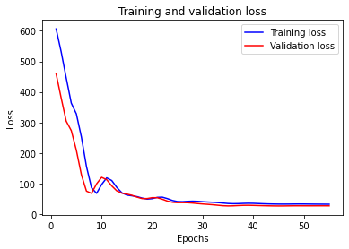

```python
import matplotlib.pyplot as plt
reg_history_dict_3 = reg_history3.history
loss_3 = reg_history_dict_3['loss']
val_loss_3 = reg_history_dict_3['val_loss']

epochs_3 = range(1, len(loss_3) + 1)

plt.plot(epochs_3, loss_3, 'b', label='Training loss')
plt.plot(epochs_3, val_loss_3, label='Validation loss', color='red') # ‘b’는 실선으로, 'bo'는 점으로 나옴
plt.title('Training and validation loss')
plt.xlabel('Epochs')
plt.ylabel('Loss')
plt.legend()

plt.show()
```

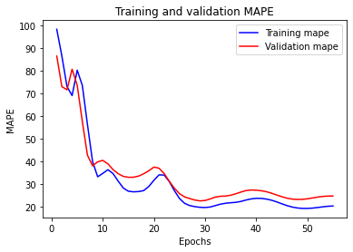

```python
plt.clf() # 그래프를 초기화합니다.
train_metric_3 = reg_history_dict_3['mape']
val_metric_3 = reg_history_dict_3['val_mape']

plt.plot(epochs_3, train_metric_3, 'b', label='Training mape')
plt.plot(epochs_3, val_metric_3, label='Validation mape', color='red')
plt.title('Training and validation MAPE')
plt.xlabel('Epochs')
plt.ylabel('MAPE')
plt.legend()

plt.show()
```

```python
y_pred_3 = model3.predict(test_features)
```

```python
# 성능평가
from sklearn.metrics import r2_score, mean_squared_error, mean_absolute_percentage_error
print('test R squared: %.3f' % r2_score(test_target, y_pred_3))
print('test MSE: %.3f' % mean_squared_error(test_target,y_pred_3))
print('tset MAPE: %.3f' % mean_absolute_percentage_error(test_target,y_pred_3))
```

```
test R squared: 0.565
test MSE: 27.767
tset MAPE: 0.225
```

4) Hidden Layer = 2, Hidden Node = [8,8] , learning rate = 0.1

```python
# Network 구조 형성
import tensorflow as tf
from tensorflow.keras import models
from tensorflow.keras import layers

# tf.set_random_seed(2021) <- 이건 tensorflow 1 version
tf.random.set_seed(2021)

# 1 #
model4 = models.Sequential() # ANN 형성
model4.add(layers.Dense(8, activation = 'relu', input_shape=(train_features.shape[1],)))
model4.add(layers.Dense(8, activation = 'relu', input_shape=(train_features.shape[1],)))
model4.add(layers.Dense(1)) # Output layer - regression은 node가 1개

# 2 #
# loss function과 optimizer 설정
adam = tf.keras.optimizers.Adam(learning_rate=0.1)

# 3 #
model4.compile(optimizer=adam, loss='mse', metrics=['mape'])

# 콜백 함수 #
es = tf.keras.callbacks.EarlyStopping(monitor='val_loss', patience=10, verbose=1, restore_best_weights=True) # Early stopping
lr = tf.keras.callbacks.ReduceLROnPlateau(monitor='val_loss', factor=0.1, min_lr=0.001) # learning rate 관련


# 4 #
# model.fit(train_data, train_targets, epochs=80, batch_size=16)
reg_history4 = model4.fit(train_features, train_target, epochs=300, batch_size=1024, validation_split=0.2,
                       callbacks=[es,lr])
```

```
Restoring model weights from the end of the best epoch.
Epoch 00073: early stopping
```

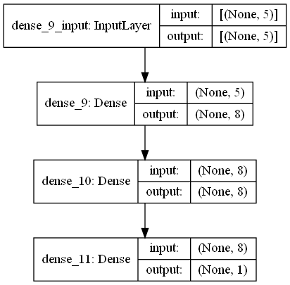

```python
plot_model(model4, to_file='network_regression_model_shapes_4.png', show_shapes=True)
```

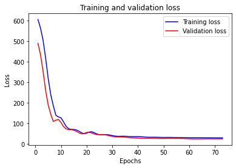

```python
import matplotlib.pyplot as plt
reg_history_dict_4 = reg_history4.history
loss_4 = reg_history_dict_4['loss']
val_loss_4 = reg_history_dict_4['val_loss']

epochs_4 = range(1, len(loss_4) + 1)

plt.plot(epochs_4, loss_4, 'b', label='Training loss')
plt.plot(epochs_4, val_loss_4, label='Validation loss', color='red') # ‘b’는 실선으로, 'bo'는 점으로 나옴
plt.title('Training and validation loss')
plt.xlabel('Epochs')
plt.ylabel('Loss')
plt.legend()

plt.show()
```

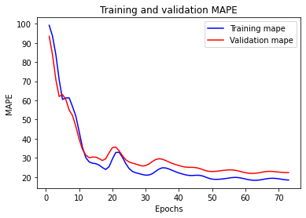

```python
plt.clf() # 그래프를 초기화합니다.
train_metric_4 = reg_history_dict_4['mape']
val_metric_4 = reg_history_dict_4['val_mape']

plt.plot(epochs_4, train_metric_4, 'b', label='Training mape')
plt.plot(epochs_4, val_metric_4, label='Validation mape', color='red')
plt.title('Training and validation MAPE')
plt.xlabel('Epochs')
plt.ylabel('MAPE')
plt.legend()

plt.show()
```

```python
y_pred_4 = model4.predict(test_features)
```

```python
# 성능평가
from sklearn.metrics import r2_score, mean_squared_error, mean_absolute_percentage_error
print('test R squared: %.3f' % r2_score(test_target, y_pred_4))
print('test MSE: %.3f' % mean_squared_error(test_target,y_pred_4))
print('tset MAPE: %.3f' % mean_absolute_percentage_error(test_target,y_pred_4))
```

```
test R squared: 0.607
test MSE: 25.080
tset MAPE: 0.205
```

5) Hidden Layer = 3, Hidden Node = [8,8,8] , learning rate = 0.1

```python
# Network 구조 형성
import tensorflow as tf
from tensorflow.keras import models
from tensorflow.keras import layers

# tf.set_random_seed(2021) <- 이건 tensorflow 1 version
tf.random.set_seed(2021)

# 1 #
model5 = models.Sequential() # ANN 형성
model5.add(layers.Dense(8, activation = 'relu', input_shape=(train_features.shape[1],)))
model5.add(layers.Dense(8, activation = 'relu', input_shape=(train_features.shape[1],)))
model5.add(layers.Dense(8, activation = 'relu', input_shape=(train_features.shape[1],)))
model5.add(layers.Dense(1)) # Output layer - regression은 node가 1개

# 2 #
# loss function과 optimizer 설정
adam = tf.keras.optimizers.Adam(learning_rate=0.1)

# 3 #
model5.compile(optimizer=adam, loss='mse', metrics=['mape'])

# 콜백 함수 #
es = tf.keras.callbacks.EarlyStopping(monitor='val_loss', patience=10, verbose=1, restore_best_weights=True) # Early stopping
lr = tf.keras.callbacks.ReduceLROnPlateau(monitor='val_loss', factor=0.1, min_lr=0.001) # learning rate 관련


# 4 #
# model.fit(train_data, train_targets, epochs=80, batch_size=16)
reg_history5 = model5.fit(train_features, train_target, epochs=300, batch_size=1024, validation_split=0.2,
                       callbacks=[es,lr])
```

```
Restoring model weights from the end of the best epoch.
Epoch 00065: early stopping
```

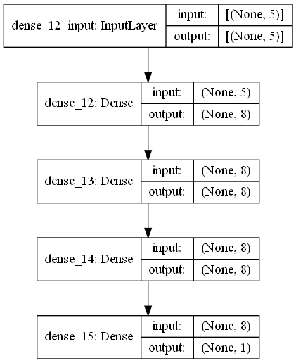

```python
plot_model(model5, to_file='network_regression_model_shapes_5.png', show_shapes=True)
```

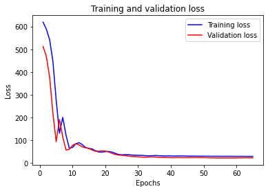

```python
import matplotlib.pyplot as plt
reg_history_dict_5 = reg_history5.history
loss_5 = reg_history_dict_5['loss']
val_loss_5 = reg_history_dict_5['val_loss']

epochs_5 = range(1, len(loss_5) + 1)

plt.plot(epochs_5, loss_5, 'b', label='Training loss')
plt.plot(epochs_5, val_loss_5, label='Validation loss', color='red') # ‘b’는 실선으로, 'bo'는 점으로 나옴
plt.title('Training and validation loss')
plt.xlabel('Epochs')
plt.ylabel('Loss')
plt.legend()

plt.show()
```

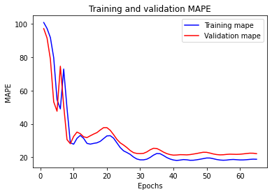

```python
plt.clf() # 그래프를 초기화합니다.
train_metric_5 = reg_history_dict_5['mape']
val_metric_5 = reg_history_dict_5['val_mape']

plt.plot(epochs_5, train_metric_5, 'b', label='Training mape')
plt.plot(epochs_5, val_metric_5, label='Validation mape', color='red')
plt.title('Training and validation MAPE')
plt.xlabel('Epochs')
plt.ylabel('MAPE')
plt.legend()

plt.show()
```

```python
y_pred_5 = model5.predict(test_features)
```

```python
# 성능평가
from sklearn.metrics import r2_score, mean_squared_error, mean_absolute_percentage_error
print('test R squared: %.3f' % r2_score(test_target, y_pred_5))
print('test MSE: %.3f' % mean_squared_error(test_target,y_pred_5))
print('tset MAPE: %.3f' % mean_absolute_percentage_error(test_target,y_pred_5))
```

```
test R squared: 0.593
test MSE: 26.018
tset MAPE: 0.202
```

6) Hidden Layer = 3, Hidden Node = [8,16,8] , learning rate = 0.1

```python
# Network 구조 형성
import tensorflow as tf
from tensorflow.keras import models
from tensorflow.keras import layers

# tf.set_random_seed(2021) <- 이건 tensorflow 1 version
tf.random.set_seed(2021)

# 1 #
model6 = models.Sequential() # ANN 형성
model6.add(layers.Dense(8, activation = 'relu', input_shape=(train_features.shape[1],)))
model6.add(layers.Dense(16, activation = 'relu', input_shape=(train_features.shape[1],)))
model6.add(layers.Dense(8, activation = 'relu', input_shape=(train_features.shape[1],)))
model6.add(layers.Dense(1)) # Output layer - regression은 node가 1개

# 2 #
# loss function과 optimizer 설정
adam = tf.keras.optimizers.Adam(learning_rate=0.1)

# 3 #
model6.compile(optimizer=adam, loss='mse', metrics=['mape'])

# 콜백 함수 #
es = tf.keras.callbacks.EarlyStopping(monitor='val_loss', patience=10, verbose=1, restore_best_weights=True) # Early stopping
lr = tf.keras.callbacks.ReduceLROnPlateau(monitor='val_loss', factor=0.1, min_lr=0.001) # learning rate 관련


# 4 #
# model.fit(train_data, train_targets, epochs=80, batch_size=16)
reg_history6 = model6.fit(train_features, train_target, epochs=300, batch_size=1024, validation_split=0.2,
                       callbacks=[es,lr])
```

```
Restoring model weights from the end of the best epoch.
Epoch 00042: early stopping
```

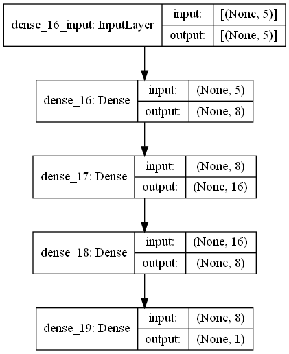

```python
plot_model(model6, to_file='network_regression_model_shapes_6.png', show_shapes=True)
```

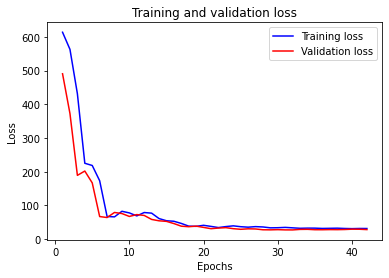

```python
import matplotlib.pyplot as plt
reg_history_dict_6 = reg_history6.history
loss_6 = reg_history_dict_6['loss']
val_loss_6 = reg_history_dict_6['val_loss']

epochs_6 = range(1, len(loss_6) + 1)

plt.plot(epochs_6, loss_6, 'b', label='Training loss')
plt.plot(epochs_6, val_loss_6, label='Validation loss', color='red') # ‘b’는 실선으로, 'bo'는 점으로 나옴
plt.title('Training and validation loss')
plt.xlabel('Epochs')
plt.ylabel('Loss')
plt.legend()

plt.show()
```

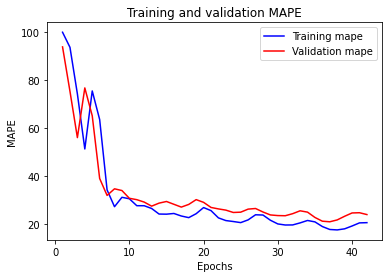

```python
plt.clf() # 그래프를 초기화합니다.
train_metric_6 = reg_history_dict_6['mape']
val_metric_6 = reg_history_dict_6['val_mape']

plt.plot(epochs_6, train_metric_6, 'b', label='Training mape')
plt.plot(epochs_6, val_metric_6, label='Validation mape', color='red')
plt.title('Training and validation MAPE')
plt.xlabel('Epochs')
plt.ylabel('MAPE')
plt.legend()

plt.show()
```

```python
y_pred_6 = model6.predict(test_features)
```

```python
# 성능평가
from sklearn.metrics import r2_score, mean_squared_error, mean_absolute_percentage_error
print('test R squared: %.3f' % r2_score(test_target, y_pred_6))
print('test MSE: %.3f' % mean_squared_error(test_target,y_pred_6))
print('tset MAPE: %.3f' % mean_absolute_percentage_error(test_target,y_pred_6))
```

```
test R squared: 0.585
test MSE: 26.480
tset MAPE: 0.222
```

## Learning Rate = 1

7) Hidden Layer = 1, Hidden Node = 8, learning rate = 1

```python
# Network 구조 형성
import tensorflow as tf
from tensorflow.keras import models
from tensorflow.keras import layers

# tf.set_random_seed(2021) <- 이건 tensorflow 1 version
tf.random.set_seed(2021)

# 1 #
model7 = models.Sequential() # ANN 형성
model7.add(layers.Dense(8, activation = 'relu', input_shape=(train_features.shape[1],)))
model7.add(layers.Dense(1)) # Output layer - regression은 node가 1개

# 2 #
# loss function과 optimizer 설정
adam = tf.keras.optimizers.Adam(learning_rate=1)

# 3 #
model7.compile(optimizer=adam, loss='mse', metrics=['mape'])

# 콜백 함수 #
es = tf.keras.callbacks.EarlyStopping(monitor='val_loss', patience=10, verbose=1, restore_best_weights=True) # Early stopping
lr = tf.keras.callbacks.ReduceLROnPlateau(monitor='val_loss', factor=0.1, min_lr=0.001) # learning rate 관련


# 4 #
# model.fit(train_data, train_targets, epochs=80, batch_size=16)
reg_history7 = model7.fit(train_features, train_target, epochs=300, batch_size=1024, validation_split=0.2,
                       callbacks=[es,lr])
```

```
Restoring model weights from the end of the best epoch.
Epoch 00029: early stopping
```

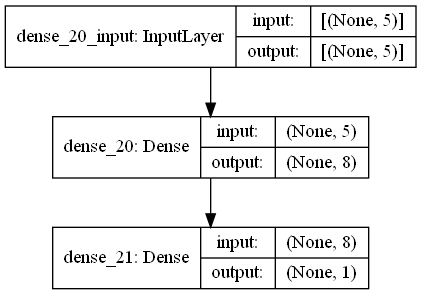

```python
plot_model(model7, to_file='network_regression_model_shapes_7.png', show_shapes=True)
```

[figure not shown]

```python
import matplotlib.pyplot as plt
reg_history_dict_7 = reg_history6.history
loss_7 = reg_history_dict_7['loss']
val_loss_7 = reg_history_dict_7['val_loss']

epochs_7 = range(1, len(loss_7) + 1)

plt.plot(epochs_7, loss_7, 'b', label='Training loss')
plt.plot(epochs_7, val_loss_7, label='Validation loss', color='red') # ‘b’는 실선으로, 'bo'는 점으로 나옴
plt.title('Training and validation loss')
plt.xlabel('Epochs')
plt.ylabel('Loss')
plt.legend()

plt.show()
```

[figure not shown]

```python
plt.clf() # 그래프를 초기화합니다.
train_metric_7 = reg_history_dict_7['mape']
val_metric_7 = reg_history_dict_7['val_mape']

plt.plot(epochs_7, train_metric_7, 'b', label='Training mape')
plt.plot(epochs_7, val_metric_7, label='Validation mape', color='red')
plt.title('Training and validation MAPE')
plt.xlabel('Epochs')
plt.ylabel('MAPE')
plt.legend()

plt.show()
```

```python
y_pred_7 = model7.predict(test_features)
```

```python
# 성능평가
from sklearn.metrics import r2_score, mean_squared_error, mean_absolute_percentage_error
print('test R squared: %.3f' % r2_score(test_target, y_pred_7))
print('test MSE: %.3f' % mean_squared_error(test_target,y_pred_7))
print('tset MAPE: %.3f' % mean_absolute_percentage_error(test_target,y_pred_7))
```

```
test R squared: 0.634
test MSE: 23.381
tset MAPE: 0.197
```

8) Hidden Layer = 1, Hidden Node = 16, learning rate = 1

```python
# Network 구조 형성
import tensorflow as tf
from tensorflow.keras import models
from tensorflow.keras import layers

# tf.set_random_seed(2021) <- 이건 tensorflow 1 version
tf.random.set_seed(2021)

# 1 #
model8 = models.Sequential() # ANN 형성
model8.add(layers.Dense(16, activation = 'relu', input_shape=(train_features.shape[1],)))
model8.add(layers.Dense(1)) # Output layer - regression은 node가 1개

# 2 #
# loss function과 optimizer 설정
adam = tf.keras.optimizers.Adam(learning_rate=1)

# 3 #
model8.compile(optimizer=adam, loss='mse', metrics=['mape'])

# 콜백 함수 #
es = tf.keras.callbacks.EarlyStopping(monitor='val_loss', patience=10, verbose=1, restore_best_weights=True) # Early stopping
lr = tf.keras.callbacks.ReduceLROnPlateau(monitor='val_loss', factor=0.1, min_lr=0.001) # learning rate 관련


# 4 #
# model.fit(train_data, train_targets, epochs=80, batch_size=16)
reg_history8 = model8.fit(train_features, train_target, epochs=300, batch_size=1024, validation_split=0.2,
                       callbacks=[es,lr])
```

```
Restoring model weights from the end of the best epoch.
Epoch 00017: early stopping
```

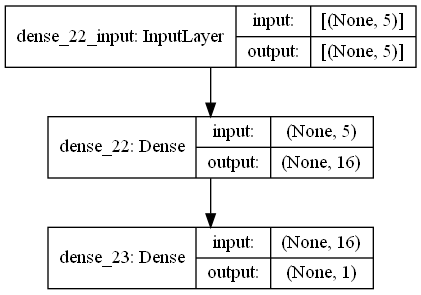

```python
plot_model(model8, to_file='network_regression_model_shapes_8.png', show_shapes=True)
```

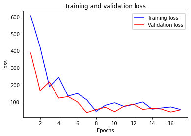

```python
import matplotlib.pyplot as plt
reg_history_dict_8 = reg_history8.history
loss_8 = reg_history_dict_8['loss']
val_loss_8 = reg_history_dict_8['val_loss']

epochs_8 = range(1, len(loss_8) + 1)

plt.plot(epochs_8, loss_8, 'b', label='Training loss')
plt.plot(epochs_8, val_loss_8, label='Validation loss', color='red') # ‘b’는 실선으로, 'bo'는 점으로 나옴
plt.title('Training and validation loss')
plt.xlabel('Epochs')
plt.ylabel('Loss')
plt.legend()

plt.show()
```

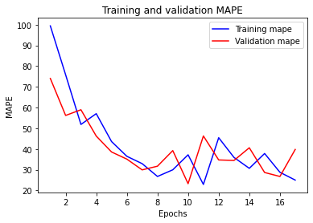

```python
plt.clf() # 그래프를 초기화합니다.
train_metric_8 = reg_history_dict_8['mape']
val_metric_8 = reg_history_dict_8['val_mape']

plt.plot(epochs_8, train_metric_8, 'b', label='Training mape')
plt.plot(epochs_8, val_metric_8, label='Validation mape', color='red')
plt.title('Training and validation MAPE')
plt.xlabel('Epochs')
plt.ylabel('MAPE')
plt.legend()

plt.show()
```

```python
y_pred_8 = model8.predict(test_features)
```

```python
# 성능평가
from sklearn.metrics import r2_score, mean_squared_error, mean_absolute_percentage_error
print('test R squared: %.3f' % r2_score(test_target, y_pred_8))
print('test MSE: %.3f' % mean_squared_error(test_target,y_pred_8))
print('tset MAPE: %.3f' % mean_absolute_percentage_error(test_target,y_pred_8))
```

```
test R squared: 0.372
test MSE: 40.122
tset MAPE: 0.276
```

9) Hidden Layer = 2, Hidden Node = [8,16], learning rate = 1

```python
# Network 구조 형성
import tensorflow as tf
from tensorflow.keras import models
from tensorflow.keras import layers

# tf.set_random_seed(2021) <- 이건 tensorflow 1 version
tf.random.set_seed(2021)

# 1 #
model9 = models.Sequential() # ANN 형성
model9.add(layers.Dense(8, activation = 'relu', input_shape=(train_features.shape[1],)))
model9.add(layers.Dense(16, activation = 'relu', input_shape=(train_features.shape[1],)))
model9.add(layers.Dense(1)) # Output layer - regression은 node가 1개

# 2 #
# loss function과 optimizer 설정
adam = tf.keras.optimizers.Adam(learning_rate=1)

# 3 #
model9.compile(optimizer=adam, loss='mse', metrics=['mape'])

# 콜백 함수 #
es = tf.keras.callbacks.EarlyStopping(monitor='val_loss', patience=10, verbose=1, restore_best_weights=True) # Early stopping
lr = tf.keras.callbacks.ReduceLROnPlateau(monitor='val_loss', factor=0.1, min_lr=0.001) # learning rate 관련


# 4 #
# model.fit(train_data, train_targets, epochs=80, batch_size=16)
reg_history9 = model9.fit(train_features, train_target, epochs=300, batch_size=1024, validation_split=0.2,
                       callbacks=[es,lr])
```

```
Restoring model weights from the end of the best epoch.
Epoch 00012: early stopping
```